# Case Study 1 - University Gender Pay Gap

Leanne Allen, Benjamin Bray, Nadiia Korchynska, Stephen Wotton

1/11/2021

# Table #1

| Year | Post-92 | Pre-92 |
| --- | --- | --- |
| 2017/18 | 15.59 | 18.72 |
| 2018/19 | 13.40 | 17.68 |
| 2019/20 | 12.64 | 16.49 |
| 2020/21 | 12.00 | 16.36 |

# Table #2 - Average Median Gender Percentage Difference For Hourly Wage

| Year | Percentage Difference |
| --- | --- |
| 2017/18 | 17.16 |
| 2018/19 | 15.54 |
| 2019/20 | 14.57 |
| 2020/21 | 14.18 |

# Plot #1 - Pre-92 and Post-92 Universities Average Gender Difference Bonus Percentages

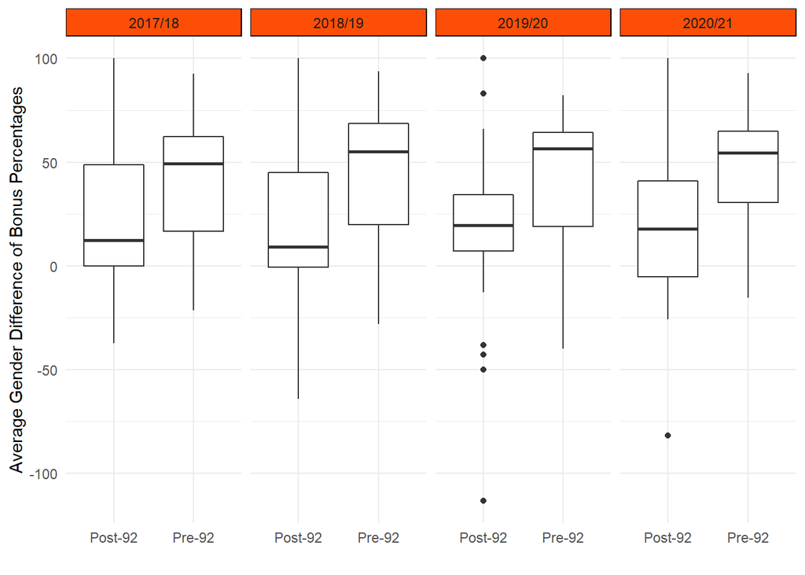

# Plot #2 - Hourly Pay Overview

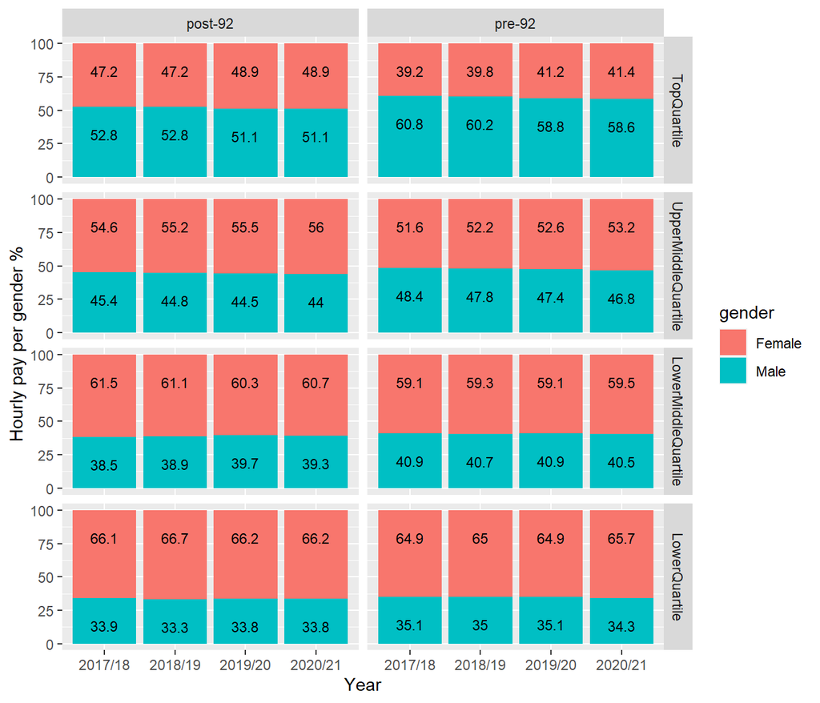

Although the trend is gradually decreasing, males dominate in the top hourly pay. Females dominate in the lower 3 quartiles of hourly pay with a trend: as pay increases the % of females in the corresponding quartile decreases. This trend is apparent across both categories of institutions, although it is more pronounced in the pre-92 group where males comprised 58.6% of the top quartile in the pre-92 group in 2020/21 compared to 51.1% in the post-92 group. This might be partially explained by there being a greater proportion of males in the pre-92 group in general compared to the post-92 group (45.6% are males in the pre-92 group vs 42.1% in the post-92 group).

## Data Sources

Data was obtained from two sources:

### Sheffield University

The department provided a set of University names split by whether they were a university prior to 1992 or were former polytechnics which gained university status post 1992.

### UK Gender Pay Gap Government Service

The UK Government provides pay gap data by gender from companies which are obligated and those which elect to submit it.

The data service is at: https://gender-pay-gap.service.gov.uk/

Note that the data diction ary can be found on page https://gender-pay-gap.service.gov.uk/viewing/download by clicking on the “About CSV data” link (which is a HTML details element without an ID hence the report is unable to link to it for you).

### Further Notes

It should be noted that twenty-seven Universities changed their employer name throughout the data which required data to be cleaned.

In data submitted for 2021/22 when the data was downloaded it contained only two universities; thus this year was excluded as the dataset was incomplete.

Of the ninety-six universities within the datasets only eighty-nine had data spanning all fours years of interest, namely: 2017/18, 2018/19, 2019/20, 2020/21.